# pierwiastki_rownan

### Rozwiązywanie równań nieliniowych

Znalezienie pierwiastków równania

\begin{equation}\label{eq:rown1} f(x)=0 \end{equation}

często wymaga użycia metod numerycznych, np. dla

$$f(x)=x sin(x)+3 cos(x)-x$$

Poznamy iteracyjne metody znajdowania miejsc zerowych funkcji, które albo wymagają przybliżenia pierwiastka, albo określenia końców przedziału zawierającego pierwiastek https://docs.scipy.org/doc/scipy/reference/optimize.html.

Warto posłużyć się wykresem funkcji, żeby zorientować się gdzie i ile pierwiastków ma badana funkcja

```python
import numpy as np
def f1(x):
    return x*np.sin(x)+3*np.cos(x)-x
```

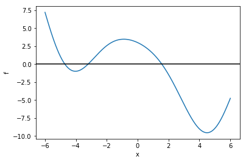

```python
%matplotlib  inline
import matplotlib.pyplot as plt
xt=np.arange(-6.0,6.02,0.01)
plt.plot(xt,f1(xt))
plt.axhline(y=0,color='k')
plt.xlabel('x')
plt.ylabel('f')

plt.show()
```

#### Metoda bisekcji

Metoda bisekcji wymaga podania końców przedziału $(a,b)$, w którym badana funkcja $f(x)$ ma pierwiastek. Na końcach takiego przedziału funkcja zmienia znak $$f(a)f(b)\leq 0$$

W każdym kroku tej metody wyznacza się środek przedziału $c=\frac{a+b}{2}$ i otrzymuje się dwa mniejsze przedziały $(a,c)$ i $(c,b)$. Dalej pracuje się z tym przedziałem w którym funkcja zmienia znak, czyli ma w nim pierwiastek. Kryterium zakończenia iteracji jest zwykle osiągniecie przez przedział zawierający pierwiastek długości mniejszej od zadanej.

Zastosujemy teraz metodę bisekcji z modułu Scipy do znalezienia pierwiastka funkcji

$$f(x)=x sin(x)+3 cos(x)-x$$

korzystając z wykresu tej funkcji wybieramy $a=0$ i $b=4$

```python
from scipy import optimize
prw=optimize.bisect(f1,0,4)
print(prw)
```

```
1.5707963267941523
```

A jak znaleźć wszystkie pierwiastki w przedziale (-6,6) ?

Będziemy badać znaki funkcji na końcach kolejnych przedziałów o szerkości $d$. Jeśli funkcja ma stały znak na końcach bieżacego przedziału, to przesuwamy się do następnego przedziału. W przeciwnym razie rozpoczynamy bisekcję.

```python
d=0.5
a=-6.1
for b in np.arange(-6,6,d):
    if np.sign(f1(a))!=np.sign(f1(b)):
        prw=optimize.bisect(f1,a,b,full_output=True)
        print("%4d   %19.16f" % (prw[1].iterations,prw[0]))
    a=b
```

```
  38   -4.7123889803860948
  38   -3.2088387319799949
  38    1.5707963267941523
```

Wykorzystaliśmy także opcję \textit{full_output}=True do znalezienia liczby iteracji niezbędnej do osiągnięcia domyślnej dokładności (2e-12)

Możemy zadać inną niż domyślna dokładność rozwiązania x podając wartości xtol i rtol

$$ |x-x^*|\leq xtol + rtol|x^*| $$

gdzie $x^*$ oznacza dokładny pierwiastek

```python
eps1=1e-14
eps2=9e-16
a=-6.1
for b in np.arange(-6,6,d):
    if np.sign(f1(a))!=np.sign(f1(b)):
        prw=optimize.bisect(f1,a,b,xtol=eps1,rtol=eps2,full_output=True)
        print("%4d   %19.16f" % (prw[1].iterations,prw[0]))
    a=b
```

```
  45   -4.7123889803846879
  46   -3.2088387319804852
  46    1.5707963267948983
```

#### Metoda Brenta

Metoda Brenta wymaga podania końców przedziału $(a,b)$, w którym badana funkcja ma pierwiastek.Metoda ta łączy metodę bisekcji z odwrotną interpolacją kwadratową - znajduje miejsce zerowe paraboli przechodzącej przez 3 punkty.

```python
# przykład użycia metody brentq()
a=-6.1
for b in np.arange(-6,6,d):
    if np.sign(f1(a))!=np.sign(f1(b)):
        prw=optimize.brentq(f1,a,b,xtol=eps1,rtol=eps2,full_output=True)
        print("%4d   %19.16f" % (prw[1].iterations,prw[0]))
    a=b
```

```
   8   -4.7123889803846897
   6   -3.2088387319804816
   7    1.5707963267948966
```

#### Metoda Riddera

Metoda Riddera składa się z następujących kroków:

\begin{enumerate} \item Określamy przedział izolacji pierwiastka $(x_1,x_2)$ oraz punkt środkowy tego przedziału $x_3=(x_1+x_2)/2$. Przypomnijmy, że funkcja ma rózne znaki na końcach przedziału izloacji pierwiastka $f1*f2<0$, gdzie $f_i\equiv f(x_i)$. \item Wprowadzamy funkcję $g(x)=f(x)\exp(a(x-x_1))$ i znajdujemy $a$ z warunku, żeby punkty $(x_1,g_1)$, $(x_2,g_2)$ i $(x_3,g_3)$ leżały na prostej \begin{equation}\label{eq:ridder_a} e^{ah}=\frac{f_3-sign(f_1)\sqrt{f_3^2-f_2f_1}}{f_2} \end{equation} gdzie $h=x_3-x_1$. \item Obliczamy punkt przecięcia prostej przechodzącej przez $(x_1,g_1)$ i $(x_3,g_3)$ z osią X \begin{equation}\label{eq:ridder_p} x_4=x_3+(x_3-x_1)\frac{sign(f_1)f_3}{\sqrt{f_3^2-f_2f_1}} \end{equation} Punkt $x_4$ będzie końcem nowego przedziału izolacji. Drugim końcem będzie $x_3$ jeśli $f_4*f_3<0$ lub jeden z punktów $x_1$,$x_2$. \item Kroki 1 - 3 powtarzamy aż długość przedziału izolacji stanie się dostatecznie mała. \end{enumerate}

Metoda Riddera ma zbieżność kwadratową.

```python
# przykład użycia metody ridder()
a=-6.1
for b in np.arange(-6,6,d):
    if np.sign(f1(a))!=np.sign(f1(b)):
        prw=optimize.ridder(f1,a,b,xtol=eps1,rtol=eps2,full_output=True)
        print("%4d   %19.16f" % (prw[1].iterations,prw[0]))
    a=b
```

```
   5   -4.7123889803846923
   4   -3.2088387319804816
   5    1.5707963267949017
```

Problemy z określeniem przedziału zawierającego pierwiastek. Jeśli funkcja na końcach przedziału ma różny znak, to w tym przedziale może być pierwiastek lub punkt osobliwy. Weźmy na przykład funkcję $$f(x)=tan(x)$$

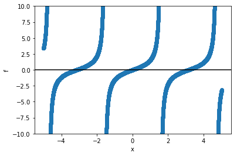

```python
#Problemy z określeniem przedziału zawierającego pierwiastek
def ft(x):
    return np.tan(x)
xt=np.arange(-5.0,5.02,0.001)
plt.scatter(xt,ft(xt))
plt.axhline(y=0,color='k')
plt.ylim(-10,10)
plt.xlabel('x')
plt.ylabel('f')

plt.show()
```

```python
# metoda riddera
a=-5.1
d=0.1
for b in np.arange(-5,5,d):
    if np.sign(ft(a))!=np.sign(ft(b)):
        prw=optimize.ridder(ft,a,b,xtol=eps1,rtol=eps2,full_output=True)
        print("%4d   %19.16f   %15.12e" % (prw[1].iterations,prw[0],ft(prw[0])))
    a=b
```

```
  29   -4.7123889803846906   1.419483893037e+15
   4   -3.1415926535897967   -3.430248998886e-15
  33   -1.5707963267948981   6.697565238617e+14
   2   -0.0000000000000050   -4.965305530480e-15
  32    1.5707963267948983   -5.830480529692e+14
   4    3.1415926535897993   6.094784257986e-15
  28    4.7123889803846932   -2.968225156589e+14
```

```python
# metoda brentq
a=-5.1
d=0.1
for b in np.arange(-5,5,d):
    if np.sign(ft(a))!=np.sign(ft(b)):
        prw=optimize.brentq(ft,a,b,xtol=eps1,rtol=eps2,full_output=True)
        print("%4d   %19.16f   %15.12e" % (prw[1].iterations,prw[0],ft(prw[0])))
    a=b
```

```
  58   -4.7123889803846843   -1.813970919495e+14
   5   -3.1415926535897905   2.786999939015e-15
  57   -1.5707963267948930   -2.767058486235e+14
   3   -0.0000000000000001   -5.925140687556e-17
  58    1.5707963267949032   -1.515127225414e+14
   5    3.1415926535897905   -2.786999939015e-15
  57    4.7123889803847039   -7.129028002109e+13
```

```python
# metoda bisekcji
a=-5.1
d=0.1
for b in np.arange(-5,5,d):
    if np.sign(ft(a))!=np.sign(ft(b)):
        prw=optimize.bisect(ft,a,b,xtol=eps1,rtol=eps2,full_output=True)
        print("%4d   %19.16f   %15.12e" % (prw[1].iterations,prw[0],ft(prw[0])))
    a=b
```

```
  43   -4.7123889803846968   1.444725453330e+14
  43   -3.1415926535898007   -7.427051887536e-15
  43   -1.5707963267949037   1.419608624542e+14
  44   -0.0000000000000007   -7.105427357602e-16
  43    1.5707963267948906   1.651135897233e+14
  43    3.1415926535897878   -5.451535198115e-15
  43    4.7123889803846843   1.813970919495e+14
```

\begin{textboxa} Obliczenie pierwiastka metodą bisekcji, Brenta, czy Riderra wymaga jeszcze sprawdzenia czy rzeczywiście jest to pierwiastek. W tym celu wystarczy sprawdzić, czy badana funkcja zwróci liczbę bliską zeru dla znalezionego pierwiastaka. \end{textboxa}

#### Metoda Newtona

Metoda Newtona nie wymaga podania przedziału zawierającego pierwiastek. Startuje ona z początkowego przybliżenia pierwiastka $x_0$ i znajduje kolejne z formuły $$ x_{n+1}=x_{n}- \frac{f(x_{n})}{f`(x_{n})} $$ gdzie $f`(x)$ jest pochodną $f(x)$.

Metoda ta jest zbieżna kwadratowo, tzn. błąd $\epsilon_n=x_n-x^*$ dla $x_n \rightarrow x^*$ maleleje kwadratowo w kolejnych iteracjach $\epsilon_{n+1}=\epsilon_n^2 \cdot constant$

Jednak problemem jest wybór $x_0$ i jeśli ten punkt nie jest blisko pierwiastka to ten schemat iteracyjny nie musi być zbieżny.

```python
# pochodna f1(x)
def pf1(x):
    return np.sin(x)+x*np.cos(x)-3*np.sin(x)-1

a=-2
prw=optimize.newton(f1,a, pf1,tol=eps1)
print("%19.16f" % (prw))
a=0
prw=optimize.newton(f1,a, pf1,tol=eps1)
print("%19.16f" % (prw))
```

```
-3.2088387319804816
 1.5707963267948966
```

```python
#jeśli w optimize.newton() full_output=True to mamy informację o zbieżności
iter=17
a=-3
prw=optimize.newton(f1,a, pf1,maxiter=iter,tol=eps1, full_output=True)
print("%4d   %19.16f" % (prw[1].iterations,prw[0]))
print("\n",prw[1])
```

```
   4   -3.2088387319804816

       converged: True
           flag: 'converged'
 function_calls: 9
     iterations: 4
           root: -3.2088387319804816
```

Szukanie wielu pierwiastków metodą Newtona. Wykorzystamy wiele punktów początkowych i usuniemy duplikaty z otzrzymanych rozwiązań. Żeby móc zidentyfikować duplikaty zaokrąglimy wyniki do k-cyfr dziesiętnych. Liczba k zależy od dokładności z jaką znaleziono rozwiązania. W tym przykładzie k=8

```python
#wiele punktów początkowych z przedzialu (-6,6)
mx0=np.arange(-6,6,0.5)
mx=optimize.newton(f1,mx0, pf1,maxiter=100,tol=eps1)
#wydruk pierwiastków
print(mx)
#Żeby znaleźć tylko różne pierwiastki
#najpierw zaokrąglimy rozwiązanie do 8 miejsc dziesiętnych
rmx=np.round(mx,8)
# następnie użyjemy np.unique() do znalezienia różnych elementów
zera,krotn=np.unique(rmx,return_counts=True)
print('\n pierwiastki=',zera)
print('\n krotnosci=',krotn)
```

```
[  -4.71238898   -4.71238898   -4.71238898   -4.71238898    7.04926423
   -3.20883873   -3.20883873   -3.20883873   -3.20883873   -4.71238898
  -23.5619449     7.04926423    1.57079633    1.57079633    1.57079633
    1.57079633    1.57079633    1.57079633    1.57079633    1.57079633
   -3.20883873 1478.11934351    7.85398163    7.04926423]

 pierwiastki= [ -23.5619449    -4.71238898   -3.20883873    1.57079633    7.04926423
    7.85398163 1478.11934351]

 krotnosci= [1 5 5 8 3 1 1]
```

```python
#wiele punktów początkowych losowo wybranych z przedzialu (-6,6)
import random
rx0=np.random.uniform(-6.0, 6.0, size=(20))
mx=optimize.newton(f1,rx0, pf1,maxiter=100,tol=eps1)

#Żeby znaleźć tylko różne pierwiastki
#najpierw zaokrąglimy rozwiązanie do 8 miejsc dziesiętnych
rmx=np.round(mx,8)
# następnie użyjemy np.unique() do znalezienia różnych elementów
zera,krotn=np.unique(rmx,return_counts=True)
print('\n pierwiastki=',zera)
print('\n krotnosci=',krotn)
```

```
 pierwiastki= [-10.43572248  -4.71238898  -3.20883873   1.57079633   7.04926423
   7.85398163]

 krotnosci= [1 4 2 7 2 4]
```

Możemy użyć tej metody optimize.newton() bez podania pochodnej funkcji. Wtedy metoda Newtona zastąpiona będzie metodą siecznych

$$ x_{n+1}=x_{n}- f(x_{n})\frac{x_{n}-x_{n-1}}{f(x_{n})-f(x_{n-1})} $$

```python
#bez pochodnej
iter=8
a=-2
prw=optimize.newton(f1,a,maxiter=iter,tol=eps1)
print("%19.16f" % (prw))
```

```
-3.2088387319804816
```

Jak używać tych metod dla funkcji jednej zmiennej z jednym lub kilkoma parametrami ?

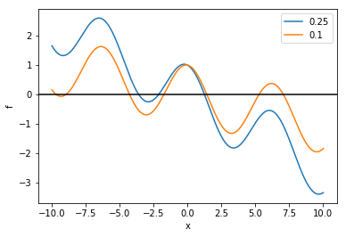

```python
def f2(x,s):
    return np.cos(x)-s*x
s=0.25
xt=np.arange(-10.0,10.02,0.01)
plt.plot(xt,f2(xt,s),label=str(s))
s=0.1
plt.plot(xt,f2(xt,s),label=str(s))
plt.axhline(y=0,color='k')
plt.legend()
plt.xlabel('x')
plt.ylabel('f')

plt.show()
```

```python
# metoda ridder()
s1=0.1
a=-10.1
d=0.5
for b in np.arange(-10,10,d):
    if np.sign(f2(a,s1))!=np.sign(f2(b,s1)):
        prw=optimize.ridder(f2,a,b,args=(s1,),full_output=True)
        print("%4d   %19.16f" % (prw[1].iterations,prw[0]))
    a=b
```

```
   5   -9.6788840184884695
   6   -8.9660164787971990
   4   -4.2710953376322713
   4   -1.7463292822538519
   5    1.4275517787637824
   4    5.2671164340754117
   5    7.0688912373426840
```

```python
#metoda newton
s1=0.25
a=-10.1
d=0.5
for b in np.arange(-10,10,d):
    if np.sign(f2(a,s1))!=np.sign(f2(b,s1)):
        prw=optimize.newton(f2,a,args=(s1,),tol=eps1)
        print("%19.16f" % (prw))
    a=b
```

```
-3.5953048671615480
-2.1333322516593336
 1.2523532340025887
```

### Pierwiastki wielomianu

W module Numpy jest metoda roots https://docs.scipy.org/doc/numpy-1.15.0/reference/generated/numpy.roots.html

znajdująca wszystkie pierwiastki (rzeczywiste i zepolone) wielomianu.

Dla wielomianu $$ w(x)=a_nx^n+a_{n-1}x^{n-1}+\ldots+a_1x+a_0 $$

macierz

\begin{equation}\label{eq:stowmac} \mathbb{A}=\left(\begin{matrix} -\frac{a_{n-1}}{a_n} &-\frac{a_{n-2}}{a_n} & \ldots &-\frac{a_1}{a_n} &-\frac{a_0}{a_n}\\ 1 & 0 &\ldots &0&0 \\ 0 & 1 &\ldots &0&0 \\ \vdots& \vdots&&\vdots&\vdots \\ 0 & 0&\ldots &1 &0 \end{matrix}\right) \end{equation}

ma wielomian charakterystyczny

$$ det\left(\mathbb{A}-x\mathbb{I}\right) $$

w postaci

$$ x^n+\frac{a_{n-1}}{a_n}x^{n-1}+\ldots+\frac{a_1}{a_n}x+\frac{a_0}{a_n} $$

Ten wielomian charakterystyczny ma takie same pierwiastki jak $w(x)$. Więc, wartości własne macierzy $\mathbb{A}$ są pierwiastkami $w(x)$.

```python
#zera wielomianu x^2+2x-4
wiel_2=[1,2,-4]
zw=np.roots(wiel_2)
print(zw)
```

```
[-3.23606798  1.23606798]
```

```python
#zera wielomianu z zespolonymi współczynnikami
wiel_3=[2,-6-6j,1,-6+6j]
zw=np.roots(wiel_3)
print(zw)
```

```
[ 2.7121868 +2.9170893j  -0.60963857-0.67275366j  0.89745177+0.75566436j]
```

```python
#sprawdzenie rozwiązania
for i in range(3):
    print(np.polyval(wiel_3,zw[i]))
```

```
(1.2434497875801753e-14+2.4868995751603507e-14j)
(5.329070518200751e-15+7.105427357601002e-15j)
(-8.881784197001252e-16+3.552713678800501e-15j)
```

```python
#zera wielomianu stopnia n z losowymi współcz.
n=20
wiel_n=np.random.randint(-1, 1, size=(n))
print('w=',wiel_n)
zwn=np.roots(wiel_n)
print('\nz=',zwn)
```

```
w= [ 0  0 -1 -1 -1 -1  0  0 -1 -1 -1 -1 -1 -1  0  0  0  0 -1 -1]

z= [ 8.66025404e-01+0.5j         8.66025404e-01-0.5j
  8.74984554e-01+0.32130825j  8.74984554e-01-0.32130825j
  5.00000000e-01+0.8660254j   5.00000000e-01-0.8660254j
  3.05311332e-16+1.15096393j  3.05311332e-16-1.15096393j
 -6.07153217e-16+1.j         -6.07153217e-16-1.j
 -5.00000000e-01+0.8660254j  -5.00000000e-01-0.8660254j
 -8.66025404e-01+0.5j        -8.66025404e-01-0.5j
 -8.74984554e-01+0.32130825j -8.74984554e-01-0.32130825j
 -1.00000000e+00+0.j        ]
```

### Rozwiązywanie układów równań nieliniowych

#### Metoda Newtona-Raphsona

Przedstawimy metodę Newtona-Raphsona dla układu 2 równań

\begin{equation}\label{eq:nr1} \begin{array}{} f_1(x_1,x_2)&= & x_1^2+x_2^2-3 &= &0 \\ f_2(x_1,x_2)&= & x_1x_2-1 &=&0 \end{array} \end{equation}

Zapiszemy ten układ w postaci wektorowej

$$ \mathbb{f(\mathbb{x})}=\mathbb{0} $$

gdzie $\mathbb{f}=(f_1,f_2)$ i $\mathbb{x}=(x_1,x_2)$.

Z rozwinięcia w szereg Taylora (z pominięciem wyrazów drugiego i wyższych rzędów) dostaniemy

$$ \mathbb{f(\mathbb{x+\Delta x})}=\mathbb{f(x)}+\mathbb{J(x)}\mathbb{\Delta x} $$

gdzie $\mathbb{J}$ jest macierzą Jacobiego z

$$ J_{ik}=\frac{\partial f_i}{\partial x_k} $$

W naszym przykładzie ta macierz ma postać

\begin{equation}\label{eq:jac} \mathbb{J}=\left(\begin{matrix} 2x_1 &2x_2 \\ x_2 &x_1 \end{matrix}\right) \end{equation}

Zakładając, że $\mathbb{f(\mathbb{x+\Delta x})}\approx\mathbb{0}$ dostajemy do rozwiązania układ równań liniowych

$$ \mathbb{J(x)}\mathbb{\Delta x}=-\mathbb{f(x)} $$

Po obliczeniu $\mathbb{\Delta x}$, np. metodą eliminacji Gaussa, dostaniemy poprawione rozwiązanie $\mathbb{x}\leftarrow\mathbb{x+\Delta x}$.

Obliczanie kolejnych $\mathbb{\Delta x}$ powtarza się aż $|\mathbb{\Delta x}|<\epsilon$.

Wykorzystamy teraz metod optimize.root z modułu Scipy do rozwiązania przykładu

```python
# funkcja dwóch zmiennych (x1=x[0],x2=x[1]) zwracająca dwie wartośći [f1,f2]
def fdz(x):
    return [x[0]**2+x[1]**2-3,\
            x[0]*x[1]-1]
```

```python
# użycie optimize.root() bez macierzy J
# początkowa wartośc
x0=np.array([1,1])
#Obliczenie pierwiastka
x1=optimize.root(fdz,x0)
if x1.success:
    print(x1.x,' ',x1.nfev)
```

```
[1.61803399 0.61803399]   19
```

```python
# użycie optimize.root() z macierzą J

# zadeklarujmy jakobian
def J(x):
    return np.array([[2*x[0],2*x[1]],[x[1],x[0]]])

# początkowa wartośc
x0=np.array([1,1])
#Obliczenie pierwiastka
x1=optimize.root(fdz,x0,jac=J)
if x1.success:
    print(x1.x,' ',x1.nfev)
```

```
[1.61803399 0.61803399]   15
```

Inny przykład. Układ 3 równań

\begin{equation}\label{eq:ur3} \begin{array}{ccc} x_1x_2-x_3^2-1 &= &0 \\ -x_1^2+x_2^2+x_1x_2x_3-2 &= &0 \\ e^{x_1}-e^{x_2}+x_3 -3 &=&0 \end{array} \end{equation}

```python
def ftz(x):
    return [x[0]*x[1]-x[2]**2-1,\
            -x[0]**2 + x[1]**2+x[0]*x[1]*x[2] -2,\
           np.exp(x[0])-np.exp(x[1])+x[2]-3]
```

```python
xtz0=np.array([1,1.0,1])
w3=optimize.root(ftz,xtz0)
if w3.success:
    print('rozwiązanie,  liczba iteracji')
    print(w3.x,' ',w3.nfev)
    print('sprawdzenie rozwiązania ')
    print(ftz(w3.x))
```

```
rozwiązanie,  liczba iteracji
[1.77767192 1.4239606  1.23747112]   15
sprawdzenie rozwiązania
[1.1405765221184083e-11, 3.6637359812630166e-12, -2.6934010577406298e-11]
```

#### Przykład z mechaniki kwantowej

Prostokątna studnia potencjału o szerokości w i głebokości V

Energie stanów związanych są rozwiązaniami 2 układów dwów równań

$$ \begin{array}{ccc} x \tan x &= &y \\ x^2+y^2 &= &r^2 \\ \end{array} \; \; \; \;\; \; \; \; \begin{array}{ccc} x \cot x &= &-y \\ x^2+y^2 &= &r^2 \\ \end{array} $$

gdzie

$x=\frac{w}{2}\sqrt{\frac{2mE}{\hbar^2}}$, $\;\;y=\frac{w}{2}\sqrt{\frac{2m(V-E)}{\hbar^2}} $, $ \;\;r^2=\frac{mVw^2}{2\hbar^2}$

W tym przypadku, nie musimy rozwiązywać układu równań, ponieważ możemy podstawić do drugiego równania wyrażenie na y z pierwszego równania. Z każdego układy dostaniemy jedno równanie.

Z pierwszego układu

$$ x^2+ x^2 \tan^2 x -r^2= 0$$

którego rozwiązania spełniają warunek $x \tan x>0$.

Z drugiego układu dostaniemy równanie

$$ x^2+ x^2 \cot^2 x -r^2= 0$$

którego rozwiązania spełniają warunek $x \cot x<0$.

```python
def row_n(x,r2):
    return x**2*(1+np.tan(x)**2)-r2

def row_p(x,r2):
    return x**2*(1+1/np.tan(x)**2)-r2
```

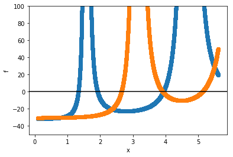

```python
# Wykresy funkcji
w=4    # w nanometrach
V=0.3  # w elektronowoltach
C=6.561710651 # stała C=m*1eV* nm^2/(2 hbar^2)
r2=C*w**2*V
r=np.sqrt(r2)
xwyk=np.arange(0.1,r,0.0001)
plt.ylim(-50,100)
plt.plot(xwyk,row_n(xwyk,r2),'o')
plt.plot(xwyk,row_p(xwyk,r2),'o')
plt.axhline(y=0,color='k')
plt.xlabel('x')
plt.ylabel('f')
plt.show()
```

```python
# Energie stanóœ związanych z rozwiązań 2 równanań nieliniowych

# Zastosujemy metodę Ridera
def poziomy(aw,aV):
    r2=C*aw**2*aV
    r=np.sqrt(r2)
    a=0.01
    d=0.1
    ezw=[]
# Kroczymy po przedziale (0,r) sprawdzając znaki funkcji na końcach małego przedziału
# (a,b) o dugości d. Gdy  te znak są różne uruchamiamy metodę Riddera
    for b in np.arange(0.1,r,d):
        if np.sign(row_n(a,r2))!=np.sign(row_n(b,r2)):
            prw_n=optimize.ridder(row_n,a,b,args=(r2,),full_output=True)
            if prw_n[0]*np.tan(prw_n[0])>0.0:
                ezw.append((prw_n[0]/aw)**2/C) # dodajemy do listy rozwiązanie w eV
        if np.sign(row_p(a,r2))!=np.sign(row_p(b,r2)):
            prw_p=optimize.ridder(row_p,a,b,args=(r2,),full_output=True)
            if prw_p[0]/np.tan(prw_p[0])<0.0:
                ezw.append((prw_p[0]/aw)**2/C) # dodajemy do listy rozwiązanie w eV
        a=b

#  Wykres energi stanów związanych

    for etym in ezw:
        plt.hlines(etym,0,aw,colors='b')

    plt.hlines(aV,-aw/2.0,0)
    plt.hlines(0,0,aw)
    plt.hlines(aV,aw,aw*3/2.0)
    plt.vlines(0,0,aV)
    plt.vlines(aw,0,aV)
    plt.xlabel('q')
    plt.ylabel('E,V')
    tyt='V='+str(aV)+'  w='+str(aw)
    plt.title(tyt)
    plt.show()

    for etym in ezw:
        print('E=',etym)
```

Teraz zbadamy kilka przypadków studni potencjału o różnych w i V używając funkcji poziomy(w,V)

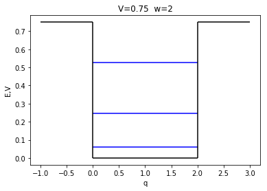

```
E= 0.06227597891064637
E= 0.24460049058551703
E= 0.5268331438882831
```

```python
poziomy(2,0.75)
```

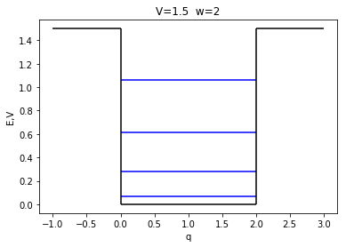

```
E= 0.06978639467060342
E= 0.277181146373662
E= 0.6149485629323356
E= 1.063139947653334
```

```python
poziomy(2,1.5)
```

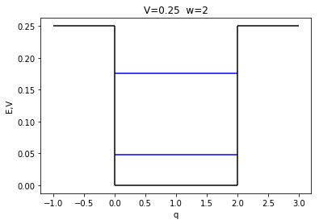

```
E= 0.04769013603184664
E= 0.17569239277154167
```

```python
poziomy(2,0.25)
```